# On the Relation Between the History of Changes and Bugs

#### RQ1: How often do changes and bugs occurin the history of methods?

- Gráfico dos projetos Contendo a Quantidade commits x Tipos de Metodos

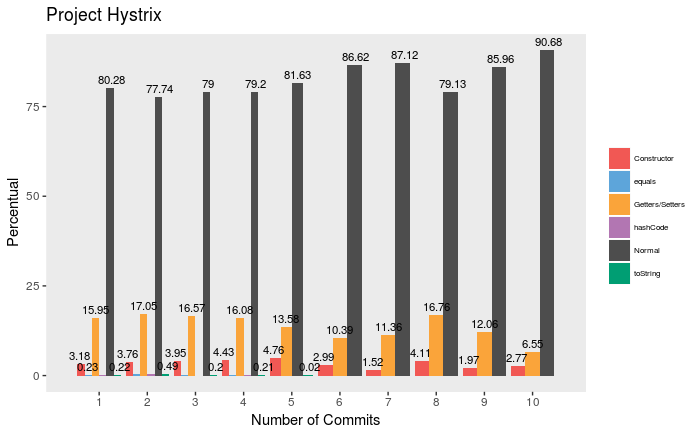

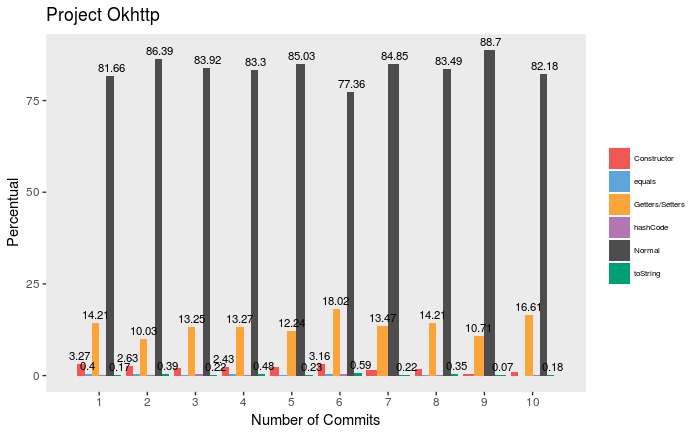

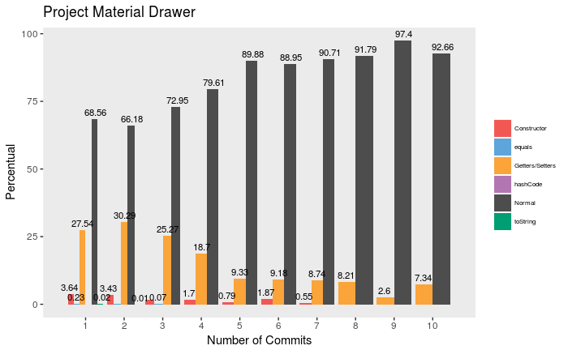

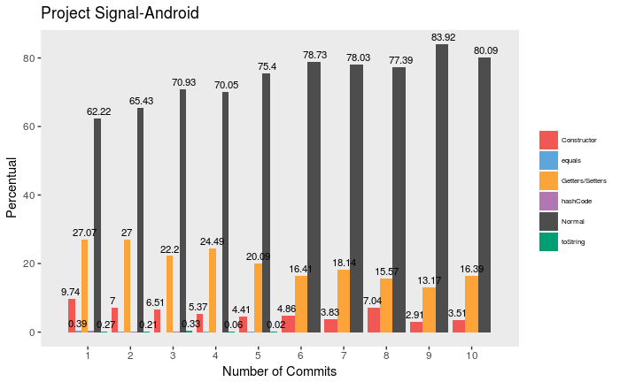

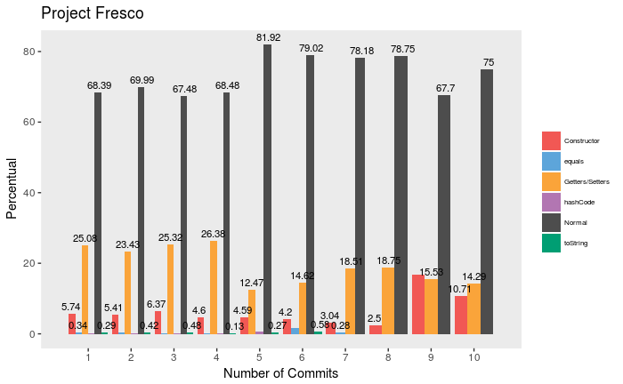

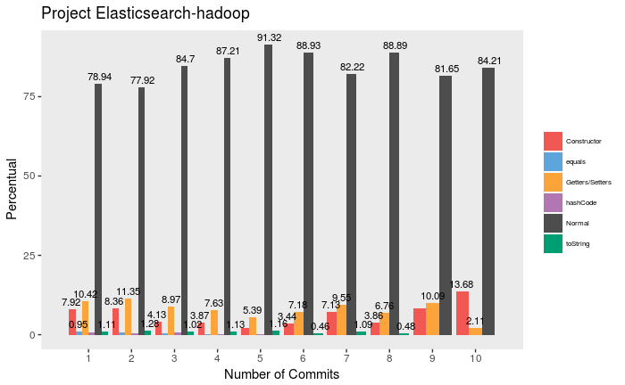

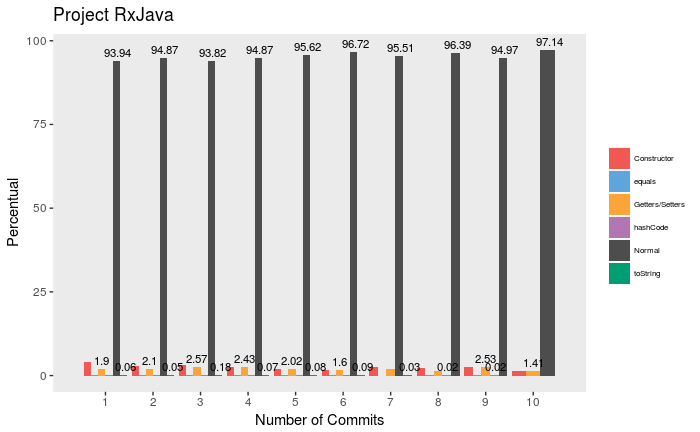

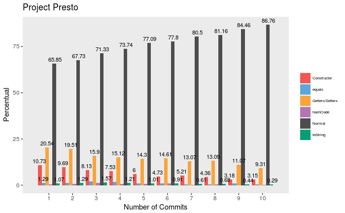

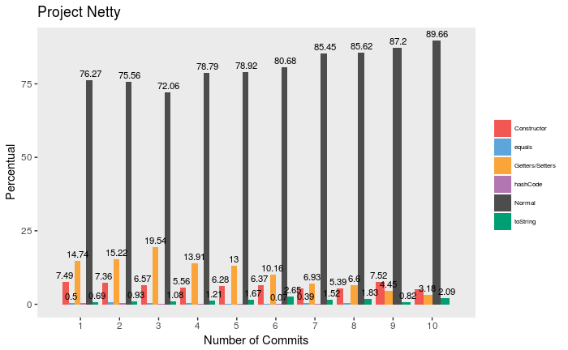

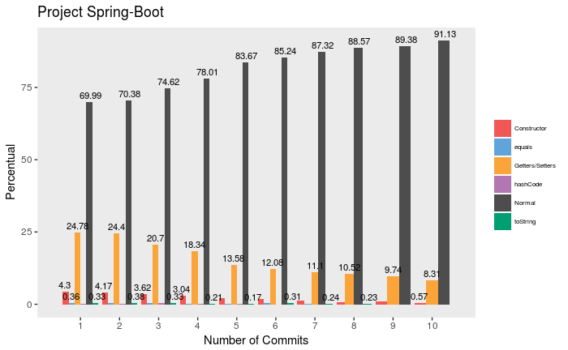

```r
projects <- unique(methods$Project)
typeMethodsData <- methods %>%
  group_by(Project, NtimeofCommits, typeMethod) %>%
  summarise(Changes = sum(Count)) %>%
  mutate(Percentual = Changes / sum(Changes) * 100) %>%
  ungroup()
#Amount
for (project in projects) {

print(ggplot(filter(typeMethodsData, Project == project, NtimeofCommits <= 10)) +
  geom_bar(aes(x = NtimeofCommits, y = Percentual, fill = typeMethod, group = typeMethod), position = "dodge", stat = "identity") +
  geom_text(aes(x = NtimeofCommits, y = Percentual, label = round(Percentual,2), group = typeMethod),
            check_overlap = TRUE, position = position_dodge(width = 1), vjust = -0.5, size = 3) +
  theme(legend.direction="vertical", legend.title = element_blank(), legend.text=element_text(size=6),
        legend.background = element_rect(fill = "transparent", colour = NA), axis.ticks.x = ) +
  theme(panel.grid.minor = element_blank(),
        panel.grid.major = element_blank(),
        plot.background = element_rect(fill = "transparent", colour = NA)) +
  ggtitle(paste0("Project ", project)) + ylab("Percentual") +
  scale_x_discrete(name ="Number of Commits", limits=c("1","2","3","4","5","6","7","8","9","10")) +
  scale_fill_manual(values=cbPalette))
}
```

- Gráfico de Todos os Projetos

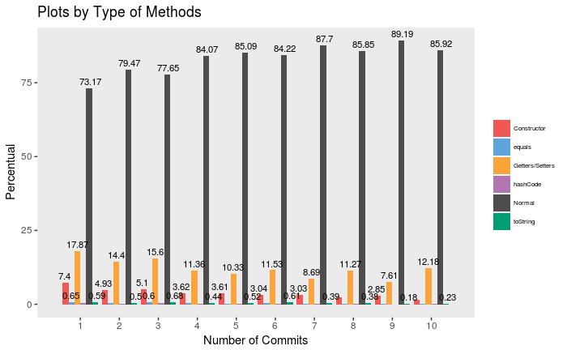

```r
#Summarize the type of methods by percentual
typeMethodsDataAll <- methods %>%
  group_by( NtimeofCommits, typeMethod) %>%
  summarise(Changes = sum(Count)) %>%
  mutate(Percentual = Changes / sum(Changes) * 100) %>%
  ungroup()
ggplot(filter(typeMethodsDataAll, NtimeofCommits <= 10)) +
    geom_bar(aes(x = NtimeofCommits, y = Percentual, fill = typeMethod, group = typeMethod), position = "dodge", stat = "identity") +
    geom_text(aes(x = NtimeofCommits, y = Percentual, label = round(Percentual,2), group = typeMethod),
              check_overlap = TRUE, position = position_dodge(width = 1), vjust = -0.5, size = 3) +
    theme(legend.direction="vertical", legend.title = element_blank(), legend.text=element_text(size=6),
          legend.background = element_rect(fill = "transparent", colour = NA), axis.ticks.x = ) +
    theme(panel.grid.minor = element_blank(),
          panel.grid.major = element_blank(),
          plot.background = element_rect(fill = "transparent", colour = NA)) +
    ggtitle("Plots by Type of Methods") + ylab("Percentual") +
    scale_x_discrete(name ="Number of Commits", limits=c("1","2","3","4","5","6","7","8","9","10")) +
    scale_fill_manual(values=cbPalette)
```

- Boxplot dos Projetos

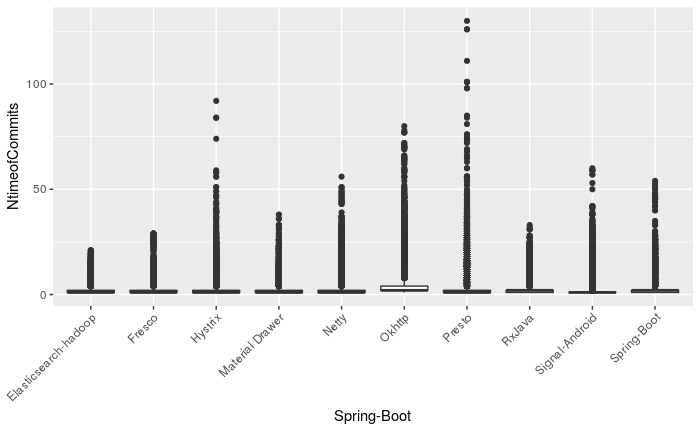

```r
#Boxplots por Projetos:
projects <- unique(methods$Project)
ggplot(methods, aes(x=Project, y=NtimeofCommits)) +
    geom_boxplot() +
    theme(axis.text.x = element_text(angle = 45, hjust = 1)) +
    scale_x_discrete(name = project)
```

Explicar as constraints como esse comportamento ocorre ao longo das constraints de maneira profunda, ou seja, explicar porque algumas constraints diminui pouco a % e algumas muito.

- **TODO** Nova tabela com o k=1:

```r
resultsC1C4<-
  sqldf(
    "SELECT Project, SUM(Count) as TotalTimeSeries,
     SUM(CASE WHEN (P2 = 1) AND (P1 = 1) THEN 1 ELSE 0 end) as 'C1',
     SUM(CASE WHEN (P2 = 1) AND (P1 = 1) AND (P4 = 1) THEN 1 ELSE 0 end) as 'C1-C2',
     SUM(CASE WHEN (P2 = 1) AND (P1 = 1) AND (P4 = 1) AND (P5 = 1) THEN 1 ELSE 0 end) as 'C1-C2-C3',
     SUM(CASE WHEN (P2 = 1) AND (P1 = 1) AND (P4 = 1) AND (P3 = 1) THEN 1 ELSE 0 end) as 'C1-C2-C4',
     SUM(CASE WHEN (P2 = 1) AND (P1 = 1) AND (P3 = 1) AND (P4 = 1) AND (P5 = 1) THEN 1 ELSE 0 end) as 'C1-C2-C3-C4'
     FROM methods
     GROUP BY Project"
  )
resultsC1C4
```

| Project | TotalTimeSeries | C1 | C1-C2 | C1-C2-C3 | C1-C2-C4 | C1-C2-C3-C4 |
| --- | --- | --- | --- | --- | --- | --- |
| Elasticsearch-hadoop | 156316 | 20911 | 15551 | 15543 | 15030 | 15022 |
| Fresco | 223666 | 13900 | 8242 | 8237 | 7934 | 7929 |
| Hystrix | 254374 | 29364 | 16846 | 16840 | 14189 | 14183 |
| Material Drawer | 77712 | 6214 | 4482 | 4476 | 4019 | 4013 |
| Netty | 1671912 | 164946 | 83138 | 83112 | 80720 | 80694 |
| Okhttp | 713307 | 190575 | 91812 | 91774 | 82907 | 82871 |
| Presto | 2432980 | 127137 | 102359 | 102318 | 94834 | 94795 |
| RxJava | 1916320 | 243430 | 132512 | 132490 | 128869 | 128847 |
| Signal-Android | 599585 | 51751 | 33471 | 33453 | 31082 | 31066 |
| Spring-Boot | 2014746 | 232384 | 136300 | 136188 | 132311 | 132199 |

[output not shown]

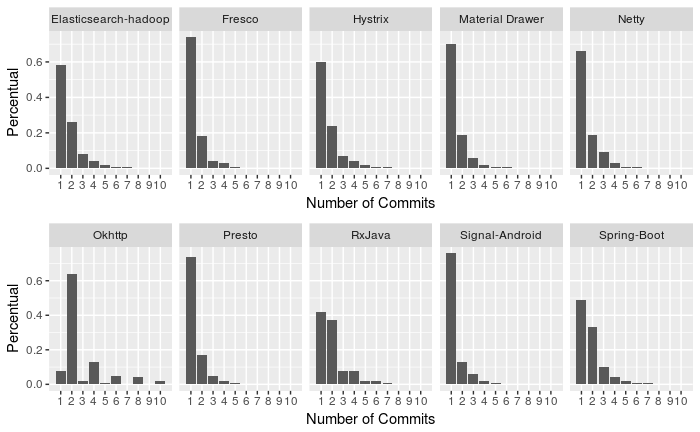

#### RQ2: How close is the relationship betweenthe history of bugs and changes?

- Comparativo entre as tecnicas:

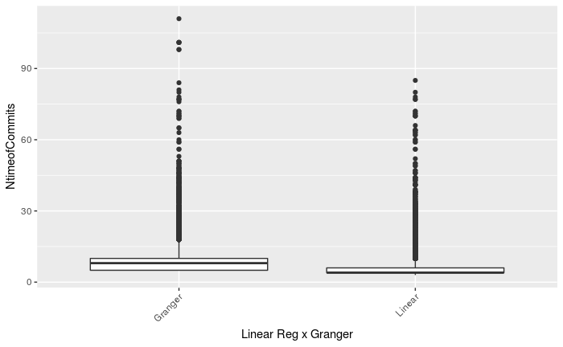

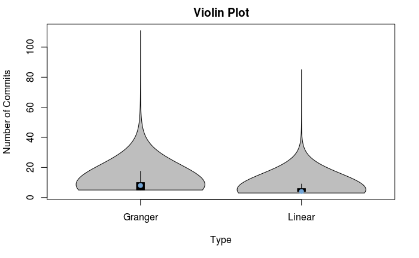

#### RQ3: Which kind of changes are mostlyrelated to the bugs insertion?

- Gráfico de Pareto de Metricas Individuais de todos os métodos que possuem bugs:

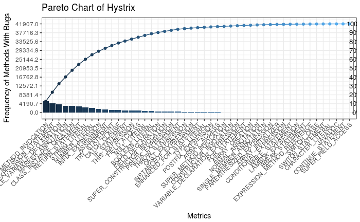

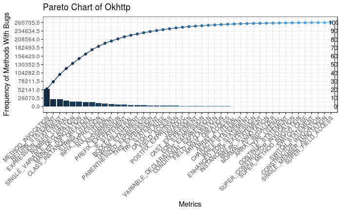

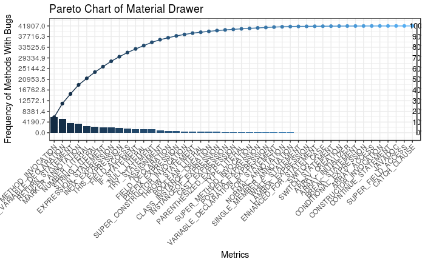

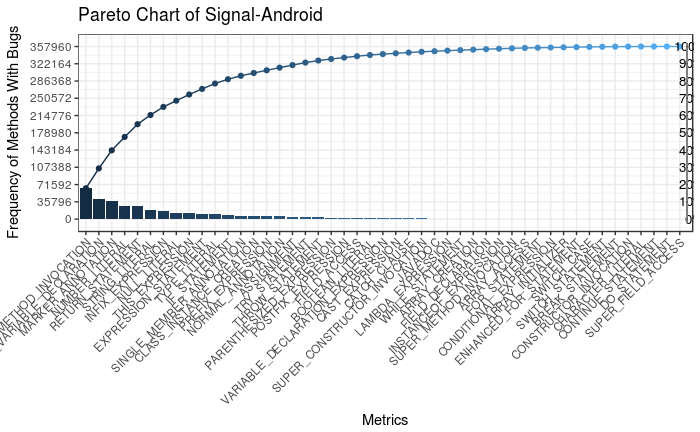

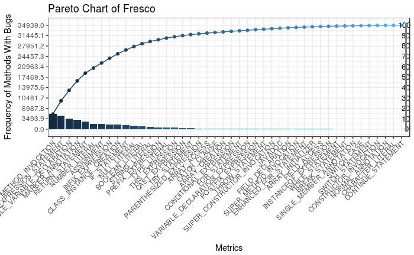

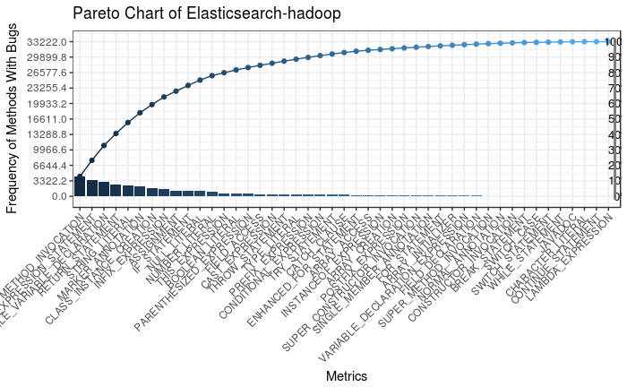

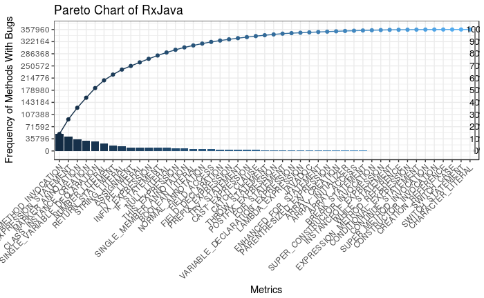

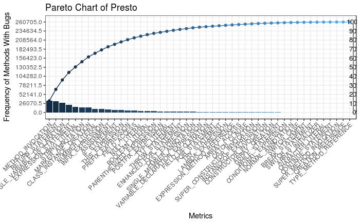

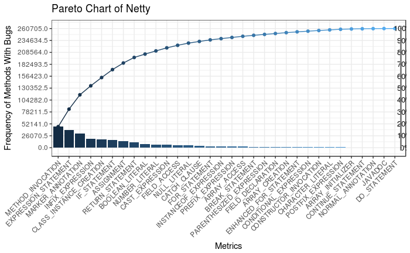

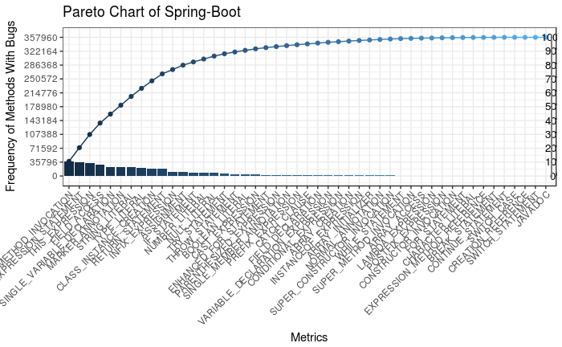

```r
#IndividualMetrics
colMethods <- c("Project", "MethodName", "Metric", "groupMetric", "changeType" ,"P1", "P2", "P3", "P4", "P5", "elementsValue", "NtimeofCommits", "Count", "GrangerPos")
#resultsClasses <- subset( resultsClasses, select = c(colClasses) )
resultsMethods <- subset( methods, select = c(colMethods) )
#Filter:D
resultsMethods <- filter(resultsMethods, P2 == 1, groupMetric != "RM")
#IndividualMetrics
indMetrics<-
  sqldf(
    "SELECT Project, Metric, SUM(Count) as Changes
    FROM resultsMethods
    WHERE changeType <> 'All'
    AND groupMetric <>'All'
    AND Metric <> 'All'
    GROUP BY Project, Metric"
  )
metrics <- c()
# Applying the function to the pareto function:
for (project in projects){
  df <- filter(indMetrics, Project == project)[,c(2,3)]
  i<-1
  for (x in 1:nrow(df)){
    for (y in 1:df$Changes[x]){
      metrics[i] <- df$Metric[x]
      i <- i + 1
    }
  }
  ggpareto(metrics, project)
}
```

```r
#Groups metrics
grpMetrics <- read.csv(file = "~/R/analysis/methods/dataMetricsGranger.csv", stringsAsFactors = FALSE)


metrics <- c()
# Applying the function to the pareto function:
for (project in projects){
  df <- filter(grpMetrics, Project == project)[,c(3,4)]
  i<-1
  for (x in 1:nrow(df)){
    for (y in 1:df$Changes[x]){
      mylist[i] <- df$Metric[x]
      i <- i + 1
    }
  }
  ggpareto(mylist, project)
}
```

[output not shown]

### RQ4:

- Changes ao longo do tempo por projetos:

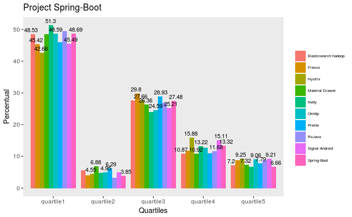

```r
dfQuartils <- as.data.frame(methods %>%
  group_by(Project, typeMethod) %>%
  summarise(quartile1 = sum(quartile1), quartile2 = sum(quartile2), quartile3 = sum(quartile3),
            quartile4 = sum(quartile4), quartile5 = sum(quartile5)))
tdfQuartils <- melt(dfQuartils, id=(c("Project", "typeMethod")))
colnames(tdfQuartils) <- c("Project", "typeMethod", "Quartiles", "Values")
#Summarize the type of methods by percentual
dfQuartilsProjects <- tdfQuartils %>%
  group_by( Project, Quartiles) %>%
  summarise(Values = sum(Values)) %>%
  mutate(Percentual = Values / sum(Values) * 100) %>%
  ungroup()
#Amount
#Changes over time by projects

ggplot(dfQuartilsProjects) +
geom_bar(aes(x = Quartiles, y = Percentual, fill = Project, group = Project), position = "dodge", stat = "identity") +
geom_text(aes(x = Quartiles, y = Percentual, label = round(Percentual,2), group = Project),
          check_overlap = TRUE, position = position_dodge(width = 1), vjust = -0.5, size = 3) +
theme(legend.direction="vertical", legend.title = element_blank(), legend.text=element_text(size=6),
      legend.background = element_rect(fill = "transparent", colour = NA), axis.ticks.x = ) +
theme(panel.grid.minor = element_blank(),
      panel.grid.major = element_blank(),
      plot.background = element_rect(fill = "transparent", colour = NA)) +
ggtitle(paste0("Project ", project)) + ylab("Percentual")
```

```r
#scale_fill_manual(values=cbPalette)
```

- Mudanças ao longo do tempo por tipos de metodos:

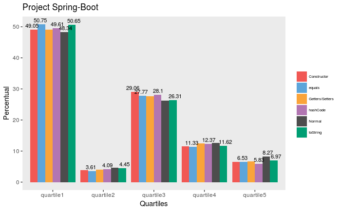

```r
#Summarize the type of methods by percentual
dfQuartilsTypes <- tdfQuartils %>%
  group_by( typeMethod, Quartiles ) %>%
  summarise(Values = sum(Values)) %>%
  mutate(Percentual = Values / sum(Values) * 100) %>%
  ungroup()
#Changes over time by types of methods
ggplot(dfQuartilsTypes) +
  geom_bar(aes(x = Quartiles, y = Percentual, fill = typeMethod, group = typeMethod), position = "dodge", stat = "identity") +
  geom_text(aes(x = Quartiles, y = Percentual, label = round(Percentual,2), group = typeMethod),
            check_overlap = TRUE, position = position_dodge(width = 1), vjust = -0.5, size = 3) +
  theme(legend.direction="vertical", legend.title = element_blank(), legend.text=element_text(size=6),
        legend.background = element_rect(fill = "transparent", colour = NA), axis.ticks.x = ) +
  theme(panel.grid.minor = element_blank(),
        panel.grid.major = element_blank(),
        plot.background = element_rect(fill = "transparent", colour = NA)) +
  ggtitle(paste0("Project ", project)) + ylab("Percentual") +
  scale_fill_manual(values=cbPalette)
```

- Picos ao longo do tempo por projetos:

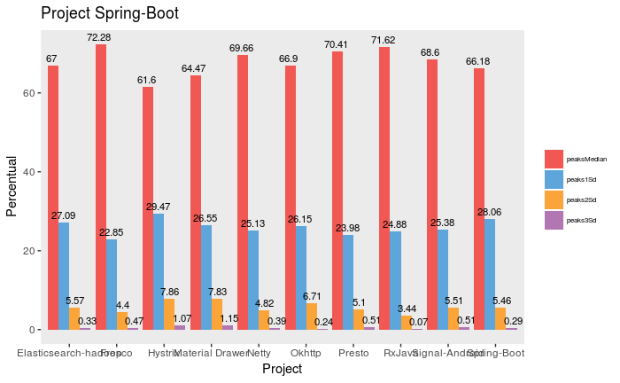

```r
dfPeaks <- as.data.frame(methods %>%
                              group_by(Project, typeMethod) %>%
                              summarise(peaksMedian = sum(peaksMedian), peaks1Sd = sum(peaks1Sd), peaks2Sd = sum(peaks2Sd),
                                        peaks3Sd = sum(peaks3Sd)))
tdfPeaks <- melt(dfPeaks, id=(c("Project", "typeMethod")))
colnames(tdfPeaks) <- c("Project", "typeMethod", "Peaks", "Values")
#Summarize the type of methods by percentual
dfPeaksProjects <- tdfPeaks %>%
  group_by( Project, Peaks) %>%
  summarise(Values = sum(Values)) %>%
  mutate(Percentual = Values / sum(Values) * 100) %>%
  ungroup()
#Amount
#Changes over time by projects
ggplot(dfPeaksProjects) +
  geom_bar(aes(x = Project, y = Percentual, fill = Peaks, group = Peaks), position = "dodge", stat = "identity") +
  geom_text(aes(x = Project, y = Percentual, label = round(Percentual,2), group = Peaks),
            check_overlap = TRUE, position = position_dodge(width = 1), vjust = -0.5, size = 3) +
  theme(legend.direction="vertical", legend.title = element_blank(), legend.text=element_text(size=6),
        legend.background = element_rect(fill = "transparent", colour = NA), axis.ticks.x = ) +
  theme(panel.grid.minor = element_blank(),
        panel.grid.major = element_blank(),
        plot.background = element_rect(fill = "transparent", colour = NA)) +
  ggtitle(paste0("Project ", project)) + ylab("Percentual") +
  scale_fill_manual(values=cbPalette)
```

- Picos ao longo do tempo por tipos de metodos:

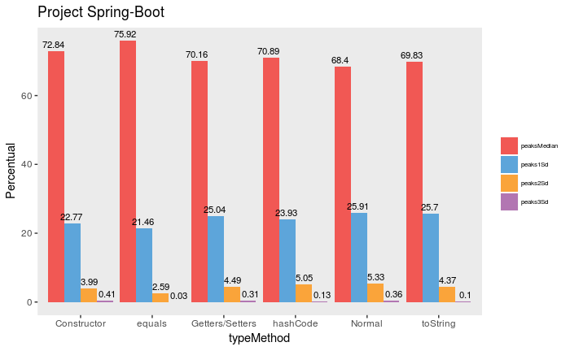

```r
dfPeaksTypes <- tdfPeaks %>%
  group_by( typeMethod, Peaks ) %>%
  summarise(Values = sum(Values)) %>%
  mutate(Percentual = Values / sum(Values) * 100) %>%
  ungroup()
#Changes over time by types of methods
ggplot(dfPeaksTypes) +
  geom_bar(aes(x = typeMethod, y = Percentual, fill = Peaks, group = Peaks), position = "dodge", stat = "identity") +
  geom_text(aes(x = typeMethod, y = Percentual, label = round(Percentual,2), group = Peaks),
            check_overlap = TRUE, position = position_dodge(width = 1), vjust = -0.5, size = 3) +
  theme(legend.direction="vertical", legend.title = element_blank(), legend.text=element_text(size=6),
        legend.background = element_rect(fill = "transparent", colour = NA), axis.ticks.x = ) +
  theme(panel.grid.minor = element_blank(),
        panel.grid.major = element_blank(),
        plot.background = element_rect(fill = "transparent", colour = NA)) +
  ggtitle(paste0("Project ", project)) + ylab("Percentual") +
  scale_fill_manual(values=cbPalette)
```